# EDA - FE - OLS

Sijia

2025-04-15

# 1 Data Wrangling

## 1.1 Data Set up

```r
property <- st_read("/Users/jiajiabao/Documents/Upenn/Practicum/2025/Data/property/opa_properties_public2.geojson") %>%
  st_transform('EPSG:2272')

property2 <- st_read("/Users/jiajiabao/Documents/Upenn/Practicum/2025/Data/property/property2.geojson") %>%
  st_transform('EPSG:2272')

property_park <- st_read("/Users/jiajiabao/Documents/Upenn/Practicum/2025/Data/property/property_park.geojson")%>%
  st_transform('EPSG:2272')

property2$distance_to_nearest_park <- property_park$distance_to_nearest_park

studyarea1 <- st_read("/Users/jiajiabao/Documents/Upenn/Practicum/2025/Data/studyarea/StudyArea.shp")%>%
  st_transform('EPSG:2272')

I676 <- st_read("/Users/jiajiabao/Documents/Upenn/Practicum/2025/Data/studyarea/I_676.shp")

studyarea_tract <- st_read("/Users/jiajiabao/Documents/Upenn/Practicum/2025/Data/studyarea/StudyArea_blockgroup_tract.shp")
philly_blockgroup <- st_read("/Users/jiajiabao/Documents/Upenn/Practicum/2025/Data/Philly_blockgroup/Philly_blockgroup.shp")

nhood <- st_read("/Users/jiajiabao/Documents/Upenn/Practicum/2025/Data/philly_neighborhoods.geojson")

landuse <- st_read("/Users/jiajiabao/Documents/Upenn/Practicum/2025/Data/landuse_clip/Land_Use_ClipLayer.shp")

I676_2 <- st_read("/Users/jiajiabao/Documents/Upenn/Practicum/2025/Data/studyarea/discontinuity.shp")%>%
  st_transform('EPSG:2272')
cpi_data <- st_read("/Users/jiajiabao/Documents/Upenn/Practicum/2025/Data/property/cpi_data.csv")

commercial<- st_read("~/Documents/Upenn/Practicum/2025/Data/Commercial_Corridors.geojson")%>%
  st_transform('EPSG:2272')
studyarea_north <- st_read("~/Documents/Upenn/Practicum/2025/Data/studyarea/studyarea_north.shp") %>%
  st_transform('EPSG:2272')

studyarea_south <- st_read("~/Documents/Upenn/Practicum/2025/Data/studyarea/studyarea_south.shp") %>%
  st_transform('EPSG:2272')

property_final <- st_read("~/Documents/Upenn/Practicum/2025/results/property_final.geojson")%>%
  st_transform('EPSG:2272')
```

## 1.2 Data Processing

### 1.2.1 property data

```r
#### clean data for city wise - sale price
colnames(cpi_data) <- c("half1", "half2", "cpi_date")
cpi_long <- cpi_data %>%
  mutate(
    Jan = `half1`, Feb = `half1`, Mar = `half1`, Apr = `half1`, May = `half1`, Jun = `half1`,
    Jul = `half2`, Aug = `half2`, Sep = `half2`, Oct = `half2`, Nov = `half2`, Dec = `half2`
  ) %>%
  select(-half1, -half2) %>%
  pivot_longer(cols = -cpi_date, names_to = "Month", values_to = "CPI") %>%
  mutate(
    Month = match(Month, month.abb),
    date = as.Date(paste(cpi_date, Month, "01", sep = "-"))
  ) %>%
  select(date, CPI)

property_philly <-property%>%
  mutate(sale_date = as.Date(sale_date, format = "%Y-%m-%d")) %>%
  filter(sale_date >= as.Date("2020-01-01") & sale_date <= as.Date("2024-12-31"))%>%
  filter(!is.na(sale_price), !is.na(total_livable_area))%>%
  mutate(
    sale_month = floor_date(sale_date, "month"))%>%
  left_join(cpi_long, by = c("sale_month" = "date"))%>%
  mutate(CPI = as.numeric(CPI))%>%
  mutate(adj_sale_price = sale_price * (340.331/CPI))%>%
  select(-sale_month, -recording_date,  -other_building,
         -assessment_date, -mailing_address_2, mailing_city_state, mailing_care_of)

#mean_price <- mean(property_philly$adj_sale_price, na.rm = TRUE)
#sd_price <- sd(property_philly$adj_sale_price, na.rm = TRUE)
#extreme_outlier <- mean_price + 5 * sd_price
price_filtered_philly <- property_philly %>%
  filter(adj_sale_price >= 100)

q_philly <- quantile(price_filtered_philly$adj_sale_price, probs = c(0.05, 0.95), na.rm = TRUE)

property_philly2 <- property_philly %>%
  filter(adj_sale_price >= q_philly[1], adj_sale_price <= q_philly[2])

#property_philly <- property_philly%>%
#  filter(adj_sale_price > 30000, adj_sale_price < extreme_outlier) %>%
#  filter(total_livable_area >= 100)

property_philly <- st_transform(property_philly2, crs = 2272)

#st_write(property_philly, "property_philly.geojson", driver = "GeoJSON", delete_dsn = TRUE)

#### clean data for study area - sale price
#study area intersection
property_studyarea <- st_intersection(property, studyarea1)

#sale price clean up and inflation adjusted
colnames(cpi_data) <- c("half1", "half2", "cpi_date")
cpi_long <- cpi_data %>%
  mutate(
    Jan = `half1`, Feb = `half1`, Mar = `half1`, Apr = `half1`, May = `half1`, Jun = `half1`,
    Jul = `half2`, Aug = `half2`, Sep = `half2`, Oct = `half2`, Nov = `half2`, Dec = `half2`
  ) %>%
  select(-half1, -half2) %>%
  pivot_longer(cols = -cpi_date, names_to = "Month", values_to = "CPI") %>%
  mutate(
    Month = match(Month, month.abb),
    date = as.Date(paste(cpi_date, Month, "01", sep = "-"))
  ) %>%
  select(date, CPI)

property_data <-property_studyarea%>%
  mutate(sale_date = as.Date(sale_date, format = "%Y-%m-%d")) %>%
  filter(!is.na(sale_price))%>%
  filter(sale_date <= as.Date("2024-12-31"))%>%
  mutate(
    sale_date = as.Date(sale_date, format = "%Y-%m-%d"),
    sale_month = floor_date(sale_date, "month"))%>%
  left_join(cpi_long, by = c("sale_month" = "date"))%>%
  mutate(CPI = as.numeric(CPI))%>%
  mutate(adj_sale_price = sale_price * (340.331/CPI)) %>%
  select(-sale_month,-recording_date,  -other_building,
         -assessment_date, -mailing_address_2, mailing_city_state, mailing_care_of, -state_code)%>%
  relocate(adj_sale_price, sale_price, .after = 2)

#mean_price <- mean(property_data$adj_sale_price, na.rm = TRUE)
#sd_price <- sd(property_data$adj_sale_price, na.rm = TRUE)
#extreme_outlier <- mean_price + 5 * sd_price

#property_data <- property_data %>%
#  filter(adj_sale_price > 30000, adj_sale_price < extreme_outlier)

#q <- quantile(property_data$adj_sale_price, probs = c(0.05, 0.98), na.rm = TRUE)
#property_data2 <- property_data %>%
#  filter(adj_sale_price >= 30000, adj_sale_price <= q[2])
price_filtered <- property_data %>%
  filter(adj_sale_price >= 100)

# Step 2: 在干净数据上计算分位数（建议）
q <- quantile(price_filtered$adj_sale_price, probs = c(0.05, 0.95), na.rm = TRUE)

# Step 3: 再从原始数据中筛选合适范围
property_data2 <- property_data %>%
  filter(adj_sale_price >= q[1], adj_sale_price <= q[2])

property1 <- st_transform(property_data2, crs = 2272)

#join attributes - I676(NS) - nhood1 (neighborhoods in study area)
property1 <- rbind(
    property1 %>% st_intersection(studyarea_north["geometry"]) %>%
      mutate(I676_NS = "north"),
    property1 %>% st_intersection(studyarea_south["geometry"]) %>%
      mutate(I676_NS = "south")
  )
nhood1 <- st_intersection(nhood, studyarea1)

#Features clean up for future FE and modeling
## Zoning
property1 <- property1%>%
  select(1:2, zoning, location, everything())

property1 <- property1 %>%
  mutate(zoning = case_when(
    location == "1310-16 VINE ST" ~ "CMX4",
    location == "252-56 N 13TH ST" ~ "CMX4",
    location == "255-57 N BROAD ST" ~ "CMX4",
    location == "451 N 12TH ST" ~ "CMX3",
    location == "453 N 12TH ST" ~"CMX3",
    location == "447 N 12TH ST" ~ "CMX3",
    location == "1108 BUTTONWOOD ST" ~ "CMX3",
    location == "1104 BUTTONWOOD ST" ~ "CMX3",
    location == "256-60 N MARVINE ST" ~ "CMX4",
    location == "820 VINE ST" ~ "CMX4",
    TRUE ~ zoning
  ))

## central air
target_locations_N <- c(
                      "1232 SUMMER ST",
                      "1030 BRANDYWINE ST",
                      "214 N 12TH ST",
                      "1021 SPRING ST")

property1 <- property1 %>%
  mutate(
    central_air = ifelse(location %in% target_locations_N & central_air == "N", "Y", central_air)
  )
## year built - clean up values of 1 and delete the other rows which are parking plot properties that have no year_built data
valid_locations <- c(
  "305-09 N 12TH ST",
  "1008-16 WOOD ST",
  "1004-06 WOOD ST",
  "211 N CAMAC ST",
  "231-33 N BROAD ST",
  "225-27 N 12TH ST"
)
property1 <- property1 %>%
  filter(location != "711-39 SPRING GARDEN ST") %>%
  mutate(year_built = as.numeric(year_built)) %>%
  mutate(
    year_built = case_when(
      location == "305-09 N 12TH ST" & year_built < 1750 ~ 1950,
      location == "1008-16 WOOD ST" & year_built < 1750 ~ 1978,
      location == "1004-06 WOOD ST" & year_built < 1750 ~ 1920,
      location == "211 N CAMAC ST" & year_built < 1750 ~ 1900,
      location == "231-33 N BROAD ST" & year_built < 1750 ~ 2020,
      location == "225-27 N 12TH ST" & year_built < 1750 ~ 2024,

      !is.na(year_built) & year_built < 1750 &
        !(location %in% c(
          "305-09 N 12TH ST",
          "1008-16 WOOD ST",
          "1004-06 WOOD ST",
          "211 N CAMAC ST",
          "231-33 N BROAD ST",
          "225-27 N 12TH ST"
        )) ~ NA_real_,
      TRUE ~ year_built
    )
  )
st_write(property_philly, "property_philly.geojson", driver = "GeoJSON", delete_dsn = TRUE)
```

```r
property_data_wgs <- st_transform(property_data, crs = 4326)

filtered_out <- property_data_wgs %>%
  filter(adj_sale_price < q[1] | adj_sale_price > q[2]) %>%
  mutate(group = "Filtered Out Property")

filtered_kept <- property_data_wgs %>%
  filter(adj_sale_price >= q[1] & adj_sale_price <= q[2]) %>%
  mutate(group = "Included Property")

filtered_out_with_zoning <- filtered_out %>%
  filter(!is.na(zoning))

filtered_out_na_zoning <- filtered_out %>%
  filter(is.na(zoning)) %>%
  mutate(group = "Filtered Out (Unknown Zoning)")

zoning_levels <- unique(filtered_out_with_zoning$zoning)
n_colors <- length(zoning_levels)

color_vec <- colorRampPalette(brewer.pal(8, "Dark2"))(n_colors)
zoning_pal <- colorFactor(palette = color_vec, domain = zoning_levels)

leaflet() %>%
  addProviderTiles("CartoDB.Positron") %>%

  addCircleMarkers(
    data = filtered_out_with_zoning,
    radius = 3,
    stroke = FALSE,
    fillOpacity = 0.8,
    color = ~zoning_pal(zoning),
    label = ~paste0("Price: $", round(adj_sale_price, 0), "<br>Zoning: ", zoning),
    group = "Filtered Out Property",
    labelOptions = labelOptions(direction = "auto")
  ) %>%

  addCircleMarkers(
    data = filtered_out_na_zoning,
    radius = 2,
    stroke = FALSE,
    fillOpacity = 0.6,
    color = "#d3d3d3",
    label = ~paste0("Price: $", round(adj_sale_price, 0), "<br>Zoning: Unknown"),
    group = "Filtered Out (Unknown Zoning)",
    labelOptions = labelOptions(direction = "auto")
  ) %>%

  addCircleMarkers(
  data = filtered_kept,
  radius = 2,
  stroke = FALSE,
  fillOpacity = 1,
  color = "black",
  label = ~paste0("Price: $", round(adj_sale_price, 0)),
  group = "Included Property",
  labelOptions = labelOptions(direction = "auto")
  ) %>%

  addLegend(
    "bottomleft",
    pal = zoning_pal,
    values = filtered_out_with_zoning$zoning,
    title = "Zoning Code (Filtered Properties)"
  ) %>%

  addLayersControl(
    overlayGroups = c("Filtered Out Property", "Filtered Out (Unknown Zoning)", "Included Property"),
    options = layersControlOptions(collapsed = FALSE)
  )
```

[interactive chart not shown]

### 1.2.2 Census Data

```r
### The method here for pushing data is diffenrent from the one we usually use cause the there is some issues when downloading the geometry data

# census block group
census_api_key("92998588496b9701036218b765c78d2ffb7aedcd", install = TRUE, overwrite = TRUE)
acs_variable_list.2023 <- load_variables(2023, "acs5", cache = TRUE)

local_shapefile <- "~/Documents/Upenn/Practicum/2025/Data/census/tl_2023_42_bg"
bg_pa <- st_read(local_shapefile, quiet = TRUE)
bg_philly <- bg_pa %>%
  filter(COUNTYFP == "101") %>%
  st_transform(2272) %>%
  select(GEOID, geometry)

block2023_attr <- get_acs(
  geography = "block group",
  variables = c("B19013_001E", "B25058_001E"),
  year = 2023,
  state = 42,
  county = 101,
  geometry = FALSE
)

block2023_attr <- block2023_attr %>%
  select(GEOID, variable, estimate) %>%
  pivot_wider(names_from = variable, values_from = estimate) %>%
  rename(
    MedHHInc = B19013_001,
    MedRent = B25058_001
  )

block2023 <- left_join(bg_philly, block2023_attr, by = "GEOID")

studyarea_tract_df <- as.data.frame(studyarea_tract) %>% select(-geometry)
block2023_studyarea <- block2023 %>% inner_join(studyarea_tract_df, by = "GEOID")

#census tract
tract_pa <- st_read("~/Documents/Upenn/Practicum/2025/Data/census/tl_2023_42_tract", quiet = TRUE)

tract_philly <- tract_pa %>%
  filter(COUNTYFP == "101") %>%
  st_transform(2272) %>%
  select(GEOID, geometry)

tract_attr <- get_acs(
  geography = "tract",
  variables = c("B25026_001E", "B15001_050E", "B15001_009E","B06012_002E"),
  year = 2023, state = 42, county = 101, geometry = FALSE
)

tract_attr_wide <- tract_attr %>%
  select(GEOID, variable, estimate) %>%
  pivot_wider(names_from = variable, values_from = estimate) %>%
  rename(
    TotalPop = B25026_001,
    FemaleBachelors = B15001_050,
    MaleBachelors = B15001_009,
    TotalPoverty = B06012_002
  )

tract2023 <- left_join(tract_philly, tract_attr_wide, by = "GEOID")
studyarea_tract_df <- as.data.frame(studyarea_tract) %>% select(-geometry)

tract2023 <- tract2023 %>%
  mutate(GEOID_trimmed = as.numeric(str_sub(GEOID, 7, 9)))

studyarea_tract_df <- studyarea_tract_df %>%
  mutate(GEOID_trimmed = as.numeric(str_sub(TRACT, 2, 4)))

tract2023_studyarea <- tract2023 %>%
  inner_join(studyarea_tract_df, by = "GEOID_trimmed")
tract_studyarea <- st_intersection(studyarea1, tract2023_studyarea)

# Property1_property2_census_join
property1 <- property1 %>%
  mutate(census_tract = as.numeric(census_tract))
tract_studyarea_selected <- tract_studyarea %>%
  select(GEOID_trimmed, TotalPoverty, MaleBachelors, FemaleBachelors, TotalPop) %>%
  st_drop_geometry()

property1_blockgroup <- st_join(property1, block2023_studyarea %>% select(GEOID, MedHHInc, MedRent),
                            join = st_intersects)

property1_geometry <- st_geometry(property1)

tract_studyarea_selected <- tract_studyarea_selected %>%
  distinct(GEOID_trimmed, .keep_all = TRUE)
property1 <- property1_blockgroup %>%
  st_drop_geometry() %>%
  left_join(tract_studyarea_selected, by = c("census_tract" = "GEOID_trimmed"))

property1 <- property1 %>%
  mutate(objectid = as.character(objectid))

property2 <- property2 %>%
  mutate(objectid = as.character(objectid))

property_combined <- property1 %>%
  left_join(property2, by = "objectid") %>%
  rename(sale_price = sale_price.y)%>%
  select(-sale_price.x)
```

### 1.2.3 Third Party Data

```r
# POI-restaurant-drink-dessert
api_key <- "AIzaSyCa-yuy1Y3n07URlR2HHg6dp_cIEouv9hs"
keywords <- c("restaurant", "dim sum restaurant", "kitchen", "desert","tea", "bubble tea","matcha", "herbal tea")
place_types <- c("restaurant", "cafe", "bakery")

studyarea_proj <- st_transform(block2023_studyarea, 2272)

grid_pts <- st_make_grid(studyarea_proj, cellsize = 2000, what = "centers")
grid_pts <- st_sf(geometry = grid_pts) %>%
  st_filter(st_buffer(studyarea_proj, 1000))

grid_pts_wgs <- st_transform(grid_pts, 4326)
coords <- st_coordinates(grid_pts_wgs)

all_responses <- list()

for (pt_idx in seq_len(nrow(coords))) {
  location <- coords[pt_idx, c(2,1)]  # lat, lng
  cat(" Querying center point", pt_idx, "at", paste(location, collapse = ", "), "\n")

  for (ptype in place_types) {
    for (kw in keywords) {
      Sys.sleep(5)
      cat("🔎", kw, "in", ptype, "\n")

      response <- google_places(
        keyword = kw,
        location = location,
        radius = 2000,
        place_type = ptype,
        key = api_key
      )

      if (is.null(response[["results"]]) || length(response[["results"]]) == 0) {
        cat("No results for:", kw, "in", ptype, "\n")
        next
      }

      page_token <- response$next_page_token
      results_list <- list(response[["results"]])
      i <- 1

      while (!is.null(page_token)) {
        Sys.sleep(10)
        response_next <- google_places(
          keyword = kw,
          location = location,
          radius = 2000,
          place_type = ptype,
          key = api_key,
          page_token = page_token
        )

        if (is.null(response_next[["results"]]) || length(response_next[["results"]]) == 0) break

        results_list[[i + 1]] <- response_next[["results"]]
        page_token <- response_next$next_page_token
        i <- i + 1
      }

      all_responses[[paste(kw, ptype, pt_idx, sep = "_")]] <- bind_rows(results_list) %>%
        filter(!is.na(place_id)) %>%
        distinct(place_id, .keep_all = TRUE)
    }
  }
}

all_responses <- all_responses[lengths(all_responses) > 0]
restaurant_results <- bind_rows(all_responses) %>%
  mutate(lat = geometry$location$lat, lng = geometry$location$lng) %>%
  select(lat, lng, name, place_id, rating) %>%
  distinct(place_id, .keep_all = TRUE)

restaurant_sf <- st_as_sf(restaurant_results, coords = c("lng", "lat"), crs = 4326)
restaurant_proj <- st_transform(restaurant_sf, 2272)

studyarea_buffer <- st_buffer(studyarea_proj, 2000)
res_poi <- st_filter(restaurant_proj, studyarea_buffer)
radius_circles <- st_buffer(st_transform(grid_pts, 2272), dist = 2000)

# POI - grocery
keywords <- c("grocery store", "supermarket", "asian grocery", "chinese supermarket",
              "korean market", "japanese grocery", "international market", "food market")

place_types <- c("supermarket", "grocery_or_supermarket", "convenience_store", "store")

studyarea_proj <- st_transform(block2023_studyarea, 2272)

grid_pts <- st_make_grid(studyarea_proj, cellsize = 2000, what = "centers")
grid_pts <- st_sf(geometry = grid_pts) %>%
  st_filter(st_buffer(studyarea_proj, 1000))

grid_pts_wgs <- st_transform(grid_pts, 4326)
coords <- st_coordinates(grid_pts_wgs)

all_responses <- list()

for (pt_idx in seq_len(nrow(coords))) {
  location <- coords[pt_idx, c(2,1)]  # lat, lng
  cat(" Querying center", pt_idx, "at", paste(location, collapse = ", "), "\n")

  for (ptype in place_types) {
    for (kw in keywords) {
      Sys.sleep(5)
      cat("🔎", kw, "in", ptype, "\n")

      response <- google_places(
        keyword = kw,
        location = location,
        radius = 2000,
        place_type = ptype,
        key = api_key
      )

      if (is.null(response[["results"]]) || length(response[["results"]]) == 0) next

      page_token <- response$next_page_token
      results_list <- list(response[["results"]])
      i <- 1

      while (!is.null(page_token)) {
        Sys.sleep(10)
        response_next <- google_places(
          keyword = kw,
          location = location,
          radius = 2000,
          place_type = ptype,
          key = api_key,
          page_token = page_token
        )
        if (is.null(response_next[["results"]]) || length(response_next[["results"]]) == 0) break

        results_list[[i + 1]] <- response_next[["results"]]
        page_token <- response_next$next_page_token
        i <- i + 1
      }

      all_responses[[paste(kw, ptype, pt_idx, sep = "_")]] <- bind_rows(results_list) %>%
        filter(!is.na(place_id)) %>%
        distinct(place_id, .keep_all = TRUE)
    }
  }
}

all_responses <- all_responses[lengths(all_responses) > 0]

grocery_results <- bind_rows(all_responses) %>%
  mutate(lat = geometry$location$lat,
         lng = geometry$location$lng) %>%
  select(lat, lng, name, place_id, rating) %>%
  distinct(place_id, .keep_all = TRUE)

grocery_sf <- st_as_sf(grocery_results, coords = c("lng", "lat"), crs = 4326)
grocery_proj <- st_transform(grocery_sf, 2272)

studyarea_buffer <- st_buffer(studyarea_proj, 2000)
grocery <- st_filter(grocery_proj, studyarea_buffer)

# property join poi
property_sf <- st_as_sf(property_combined, sf_column_name = "geometry")
property_proj <- st_transform(property_sf, 2272)
grocery_proj <- st_transform(grocery, 2272)
restaurant_proj <- st_transform(res_poi, 2272)

grocery_idx <- st_nearest_feature(property_proj, grocery_proj)

property_proj$nearest_grocery_name <- grocery_proj$name[grocery_idx]
property_proj$nearest_grocery_dist <- st_distance(
  property_proj,
  grocery_proj[grocery_idx, ],
  by_element = TRUE
)
restaurant_idx <- st_nearest_feature(property_proj, restaurant_proj)
property_proj$nearest_restaurant_name <- restaurant_proj$name[restaurant_idx]
property_proj$nearest_restaurant_dist <- st_distance(
  property_proj,
  restaurant_proj[restaurant_idx, ],
  by_element = TRUE
)
property_proj$nearest_grocery_dist_m <- as.numeric(property_proj$nearest_grocery_dist)
property_proj$nearest_restaurant_dist_m <- as.numeric(property_proj$nearest_restaurant_dist)
clean_property_poi_distances <- function(property_sf) {
  property_sf %>%
    mutate(
      nearest_grocery_dist_m = as.numeric(nearest_grocery_dist),
      nearest_restaurant_dist_m = as.numeric(nearest_restaurant_dist)) %>%
    select(
      -nearest_grocery_dist,
      -nearest_restaurant_dist
    )
}
property_final <- clean_property_poi_distances(property_proj)
st_write(property_final, "property_final.geojson", driver = "GeoJSON", delete_dsn = TRUE)
```

# 2 Exploratory Data Analysis

## 2.1 Highway Impacts

### 2.1.1 Linear Relationship: Sale Price vs. Distance to I-676 by Zoning

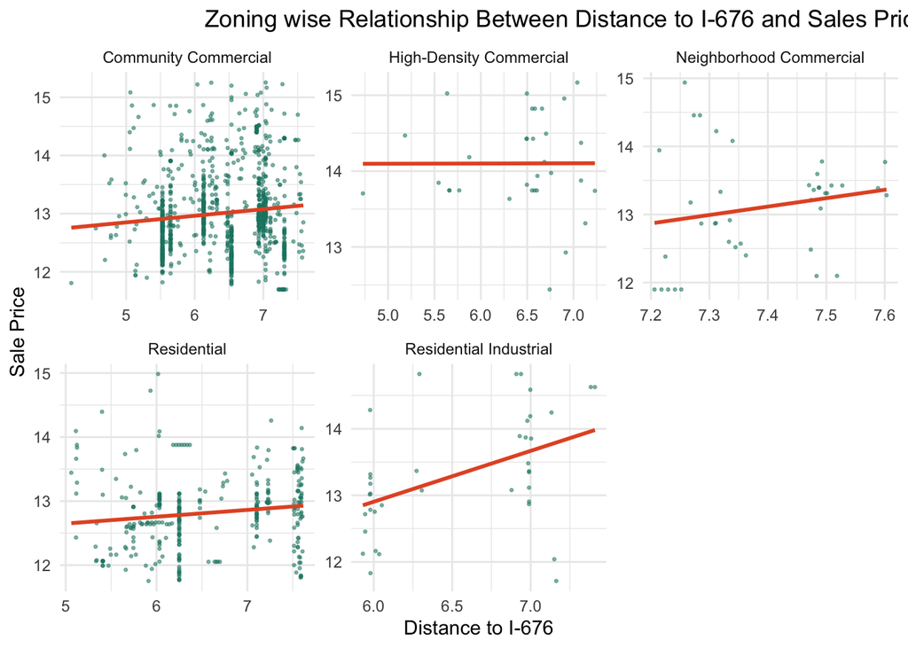

```r
property_filtered <- property_final
property_filtered <- st_as_sf(property_filtered, sf_column_name = "geometry")

avg_price_zoning <- property_filtered %>%
  st_drop_geometry() %>%
  group_by(zoning) %>%
  summarise(avg_price_zoning = mean(adj_sale_price, na.rm = TRUE)) %>%
  ungroup()

property_filtered <- property_filtered %>%
  left_join(avg_price_zoning, by = "zoning")%>%
  filter(location != "711-39 SPRING GARDEN ST")

property_filtered <- property_filtered %>%
  mutate(zoning_group = case_when(
    zoning %in% c("CMX5", "ICMX") ~ "High-Density Commercial",
    zoning %in% c("IRMX") ~ "Residential Industrial",
    zoning %in% c("RM1", "RM4", "RMX3", "RSA5") ~ "Residential",
    zoning %in% c("CMX2.5", "CMX2", "CMX1") ~ "Neighborhood Commercial",
    zoning %in% c("CMX3", "CMX4") ~ "Community Commercial",
    TRUE ~ "Other"
  ))

avg_price_group <- property_filtered %>%
  st_drop_geometry() %>%
  group_by(zoning_group) %>%
  summarise(avg_adj_sale_price = mean(adj_sale_price, na.rm = TRUE)) %>%
  ungroup()

property_filtered <- property_filtered %>%
  left_join(avg_price_group, by = "zoning_group")


ggplot(property_filtered %>% filter(!is.na(zoning_group) & zoning_group != "Other"),
       aes(x = log1p(distance_to_I676), y = log1p(adj_sale_price))) +
  geom_point(alpha = 0.5, size = 0.5, color = "#1B8370") +
  geom_smooth(method = "lm", se = FALSE, color = "#E4572E") +
  facet_wrap(~ zoning_group, scales = "free") +
  theme_minimal() +
  labs(title = "                      Zoning wise Relationship Between Distance to I-676 and Sales Price",
       x = "Distance to I-676",
       y = "Sale Price")
```

### 2.1.2 Linear Relationship: Sale Price vs. Distance to I-676 by Neighborhood

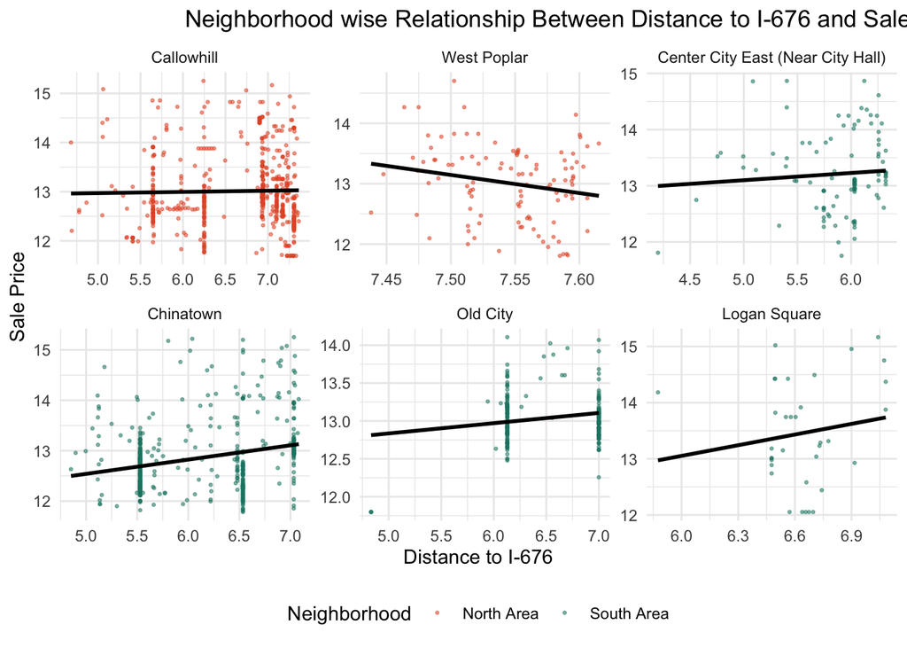

```r
property_with_nhood <- st_join(property_filtered, nhood1, join = st_intersects)

nhood_summary <- property_with_nhood %>%
  group_by(NAME) %>%
  summarise(
    avg_sale_price = mean(adj_sale_price, na.rm = TRUE),
    avg_distance = mean(distance_to_I676, na.rm = TRUE)
  ) %>%
  ungroup()
nhood_map <- st_join(nhood1, nhood_summary, by = "NAME")

property_logansquare_split <- property_filtered %>%
  mutate(
    nhoods_name = case_when(
      GEOID %in% c("421010003003") ~ "Logan Square",
      GEOID %in% c("421010125013", "421010125014") ~ NA_character_,
      str_to_title(str_replace_all(nhoods_name, "_", " ")) == "Center City" ~ "Center City East (Near City Hall)",
      TRUE ~ str_to_title(str_replace_all(nhoods_name, "_", " "))
    )
  ) %>%
  filter(!is.na(nhoods_name))

avg_price_nhoods <- property_logansquare_split %>%
  st_drop_geometry() %>%
  group_by(nhoods_name) %>%
  summarise(avg_sale_price = mean(adj_sale_price, na.rm = TRUE)) %>%
  ungroup()

highlight_nhoods <- c( "Callowhill", "West Poplar")
green_nhoods <- c("Center City East (Near City Hall)", "Chinatown", "Old City", "Logan Square")

property_logansquare_split$nhoods_name <- factor(
  property_logansquare_split$nhoods_name,
  levels = c(highlight_nhoods, green_nhoods)
)
ggplot(property_logansquare_split %>% filter(!is.na(nhoods_name)),
       aes(x = log1p(distance_to_I676), y = log1p(adj_sale_price),
           color = ifelse(nhoods_name %in% highlight_nhoods, "North Area", "South Area"))) +
  geom_point(alpha = 0.5, size = 0.5) +
  geom_smooth(method = "lm", se = FALSE, color = "black") +
  facet_wrap(~ nhoods_name, scales = "free", nrow = 2) +
  scale_color_manual(values = c("North Area" = "#E4572E", "South Area" = "#1B8370")) +
  theme_minimal() +
  theme(
    legend.position = "bottom",
    legend.justification = c(0.5, -0.2)
  ) +
  labs(
        title = "                   Neighborhood wise Relationship Between Distance to I-676 and Sales Price",
       x = "Distance to I-676",
       y = "Sale Price",
    color = "Neighborhood"
  )
```

### 2.1.3 Correlation Matrix

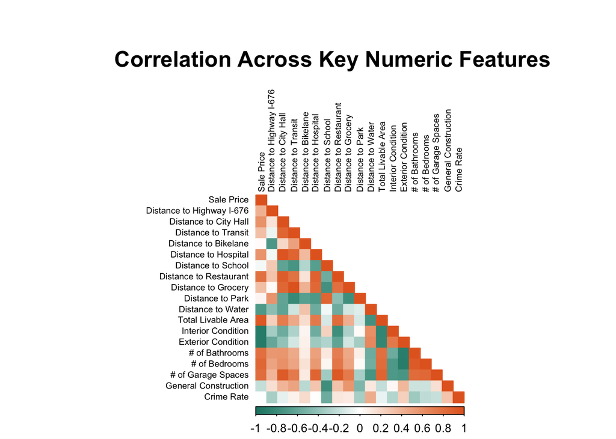

```r
lm1_property <- property_final %>%
  st_drop_geometry() %>%
  select(
    adj_sale_price,
    distance_to_I676,
    distance_to_city_hall,
    distance_to_nearest_transit,
    distance_to_nearest_bikelane,
    distance_to_nearest_hospital,
    distance_to_nearest_school,
    nearest_restaurant_dist_m,
    nearest_grocery_dist_m,
    distance_to_nearest_park,
    distance_to_nearest_water,
    total_livable_area,
    interior_condition,
    exterior_condition,
    number_of_bathrooms,
    number_of_bedrooms,
    garage_spaces,
    general_construction,
    crime_nn5
  ) %>%
  mutate(across(everything(), as.numeric)) %>%
  na.omit()

cor_matrix <- cor(lm1_property, use = "complete.obs")

var_labels <- c(
  "adj_sale_price" = "Sale Price",
  "distance_to_I676" = "Distance to Highway I-676",
  "distance_to_city_hall" = "Distance to City Hall",
  "distance_to_nearest_transit" = "Distance to Transit",
  "distance_to_nearest_bikelane" = "Distance to Bikelane",
  "distance_to_nearest_school" = "Distance to School",
  "nearest_restaurant_dist_m" = "Distance to Restaurant",
  "nearest_grocery_dist_m" = "Distance to Grocery",
  "distance_to_nearest_hospital" = "Distance to Hospital",
  "distance_to_nearest_park" = "Distance to Park",
  "distance_to_nearest_water" = "Distance to Water",
  "total_livable_area" = "Total Livable Area",
  "interior_condition" = "Interior Condition",
  "exterior_condition" = "Exterior Condition",
  "number_of_bathrooms" = "# of Bathrooms",
  "number_of_bedrooms" = "# of Bedrooms",
  "garage_spaces" = "# of Garage Spaces",
  "crime_nn5" = "Crime Rate",
  "general_construction" = "General Construction"
)

colnames(cor_matrix) <- var_labels[colnames(cor_matrix)]
rownames(cor_matrix) <- var_labels[rownames(cor_matrix)]

corrplot(
  cor_matrix,
  method = "color",
  col = colorRampPalette(c("#1B8370", "white", "#E46726"))(200),
  type = "lower",
  tl.pos = "lt",
  tl.col = "black",
  tl.cex = 0.6,
  mar = c(0, 0, 5, 0)
)

title(
  main = "Correlation Across Key Numeric Features",
  cex.main = 1.5,
  font.main = 2,
  line = 0.3,
  adj = 0.6
)
```

## 2.2 Feature Engineering

```r
median_bedroom <- median(as.numeric(as.character(property_final$number_of_bedrooms)), na.rm = TRUE)
median_bathroom <- median(as.numeric(as.character(property_final$number_of_bathrooms)), na.rm = TRUE)

property_CT <- property_final %>%
  filter(!zoning %in% c("I2", "SPPOA"))%>%
  mutate(
        # Neighborhood Name
    nhoods_name = case_when(
      nhoods_name %in% c("CENTER_CITY", "LOGAN_SQUARE") ~ "WEST_PART",
      TRUE ~ nhoods_name
    ),

    # Land Use
    landuse = case_when(
      landuse %in% c("Park/Open Space", "Other/Unknown", "Commercial Business/Professional") ~ "Open Space/Business",
      landuse %in% c("Commercial Consumer", "Commercial Mixed Residential",
                     "Industrial", "Transportation", "Culture/Amusement") ~ "Commercial",
      landuse %in% c("Civic/Institution", "Residential High") ~ "Residential High/Civic",
      TRUE ~ landuse
    ),

    # LPSS Category
#    LPSS_PER1000 = case_when(
#      LPSS_PER1000 < 45 ~ "low",
#      LPSS_PER1000 >= 45 & LPSS_PER1000 <= 60.70941337 ~ "mid",
#      LPSS_PER1000 %in% c(60.70941337, 131.86813187) ~ "high",
#      TRUE ~ "Unknown"
#    ),
#    LPSS_PER1000 = factor(LPSS_PER1000, levels = c("low", "mid", "Unknown")),

    # HPSS Category
#    HPSS_PER1000 = case_when(
#      HPSS_PER1000 < 5.6 ~ "low",
#     HPSS_PER1000 >= 5.6 & HPSS_PER1000 <= 7.3 ~ "mid",
#      HPSS_PER1000 >= 7.3 ~ "high",
#      TRUE ~ "Unknown"
#    ),
#    HPSS_PER1000 = factor(HPSS_PER1000, levels = c("low", "mid", "Unknown")),

    # Year Built
    year_built = as.numeric(year_built),
    year_built_missing = ifelse(is.na(year_built), 1, 0),
#    year_built = case_when(
#      is.na(year_built) ~ "Unknown",
#      TRUE ~ as.character(year_built)
#    ),
#    year_built = factor(year_built),

    year_built_group = case_when(
     year_built < 1900 ~ "1900 Before",
     year_built >= 1900 & year_built < 1930 ~ "1900- 1930",
     year_built >= 1930 & year_built < 1970 ~ "1930 - 1970",
     year_built >= 1970 & year_built < 2010 ~ "1970 - 2010",
     year_built >= 2010 ~ "2010+",
      TRUE ~ "Unknown"
    ),
    year_built_group = factor(year_built_group, levels = c("1900 Before","1900- 1930","1930 - 1970","1970 - 2010","2010+","Unknown")),

    # Log Transforms
    log_price = log(adj_sale_price),
    log_dist_highway = log(distance_to_I676 + 1),

    # Central Air
    central_air = case_when(
      central_air %in% c("Y", "1")  ~ "Y",
      central_air %in% c("N", "0") ~ "N",
      TRUE ~ "Unknown"
    ),
    central_air = factor(central_air),
    central_air_missing = ifelse(central_air == "Unknown", 1, 0),

    # Garage Spaces
    garage_spaces_missing = ifelse(is.na(garage_spaces), 1, 0),
    garage_spaces = case_when(
#      is.na(garage_spaces) ~ "Unknown",
      garage_spaces == 0 | garage_spaces == 1 ~ "less than 2",
      TRUE ~ "2 or more"
    ),
    garage_spaces = factor(garage_spaces),

    # Bedrooms
    number_of_bedrooms = as.numeric(as.character(number_of_bedrooms)),
    number_of_bedrooms_missing = ifelse(is.na(number_of_bedrooms), 1, 0),
    number_of_bedrooms_filled = ifelse(is.na(number_of_bedrooms), median_bedroom, number_of_bedrooms),
    number_of_bedrooms = case_when(
      is.na(number_of_bedrooms) ~ "Unknown",
      number_of_bedrooms == 0 ~ "0",
      number_of_bedrooms == 1 ~ "1",
      number_of_bedrooms %in% c(2, 3) ~ "2",
      number_of_bedrooms %in% c(5, 6) ~ "3",
      number_of_bedrooms == 4 ~"4",
      number_of_bedrooms %in% c(7, 9, 12) ~ "5"
    ),
    number_of_bedrooms = factor(number_of_bedrooms),

    # Bathrooms
    number_of_bathrooms = as.numeric(as.character(number_of_bathrooms)),
    number_of_bathrooms_missing = ifelse(is.na(number_of_bathrooms), 1, 0),
    number_of_bathrooms_filled = ifelse(is.na(number_of_bathrooms), median_bathroom, number_of_bathrooms),
    number_of_bathrooms = case_when(
      number_of_bathrooms == 0 ~ "0",
      number_of_bathrooms == 1 ~ "1",
      number_of_bathrooms == 2 ~ "2",
      number_of_bathrooms %in% c(3, 4, 5) ~ "3-5",
      number_of_bathrooms == 6 ~ "6",
      number_of_bathrooms == 7 ~ "7",
      TRUE ~ "Unknown"
    ),
    number_of_bathrooms = factor(number_of_bathrooms),

    # Total Livable Area
    total_livable_area = ifelse(is.na(total_livable_area) | total_livable_area == 1, 0, total_livable_area),

    # Quality Grade
    quality_grade = case_when(
      quality_grade %in% c("A ", "A-") | is.na(quality_grade) ~ "Good",
      quality_grade %in% c("3 ", "C+", "C")  ~ "Average",
      TRUE ~ "Below Average"
    ),
    quality_grade = factor(quality_grade, levels = c("Good", "Average", "Below Average")),
    quality_grade_missing = ifelse(is.na(quality_grade), 1, 0),

    # Construction
    general_construction = as.character(general_construction),
    general_construction = case_when(
      is.na(general_construction) ~ "Unknown",
      TRUE ~ general_construction
    ),
    general_construction = factor(general_construction),
    general_construction_missing = ifelse(general_construction == "Unknown", 1, 0),

    # Separate Utilities
    separate_utilities = case_when(
      is.na(separate_utilities) ~ "Unknown",
      TRUE ~ separate_utilities
    ),
    separate_utilities = factor(separate_utilities, levels = c("A", "B", "C", "Unknown")),
    separate_utilities_missing = ifelse(separate_utilities == "Unknown", 1, 0),

    # Exterior Condition
    exterior_condition = case_when(
      exterior_condition == 2 ~ "Good",
      exterior_condition %in% c(1, 6, 7) | is.na(exterior_condition) ~ "Average",
      exterior_condition %in% c(3, 4, 5) ~ "Below Average"
 #     TRUE ~ "Unknown"
    ),
    exterior_condition = factor(exterior_condition),

    # Interior Condition
    interior_condition = case_when(
      interior_condition %in% c(1,2,7) | is.na(interior_condition) ~ "Good",
      interior_condition %in% c(3,4,5) ~ "Average",
      interior_condition %in% c(6) ~ "Below Average",
      TRUE ~ "Unknown"
    ),
    interior_condition = factor(interior_condition),

    # Category Code
    category_code_original = as.character(category_code),
    category_code_group = case_when(
      category_code == "12" ~ "6 ",
      category_code == "14" ~ "2 ",
      category_code == "10" ~ "4 ",
      category_code == "15" ~ "5 ",
      category_code == "16" ~ "4 ",
      category_code == "7 "  ~ "4 ",
      category_code == "8 "  ~ "6 ",
      category_code == "9 "  ~ "2 ",
      category_code %in% c("1 ", "2 ", "3 ", "4 ", "5 ", "6 ") ~ category_code,
      TRUE ~ "Other"
    ),
    category_code = factor(category_code_group),

    # Zoning
    zoning_group = case_when(
      zoning %in% c("CMX5") ~ "CMX5",
      zoning %in% c("IRMX") ~ "IRMX",
      zoning %in% c("RM1", "RM2", "RM4") ~ "RM",
      zoning %in% c("RMX3") ~ "RMX3",
      zoning %in% c("RSA5") ~ "RSA5",
      zoning %in% c("ICMX") ~ "ICMX",
      zoning %in% c("SPPOA") ~ "SPPOA",
      zoning %in% c("I2") ~ "I2",
      zoning %in% c("CMX2.5", "CMX2", "CMX1") ~ "CMX(1,2,2.5)",
      zoning %in% c("CMX3", "CMX4") ~ "CMX(3,4)",
      TRUE ~ "Other"
    ),
    zoning_group = factor(zoning_group),

    zoning = case_when(
      is.na(zoning) ~ "Unknown",
      TRUE ~ zoning
    ),
    zoning = factor(zoning),
    zip_code = factor(zip_code)
  )

mean_depth <- mean(property_CT$depth, na.rm = TRUE)
property_CT$depth[is.na(property_CT$depth)] <- mean_depth

st_write(property_CT, "property_CT_FE.geojson", driver = "GeoJSON", delete_dsn = TRUE)
```

### 2.2.1 Log Transformation

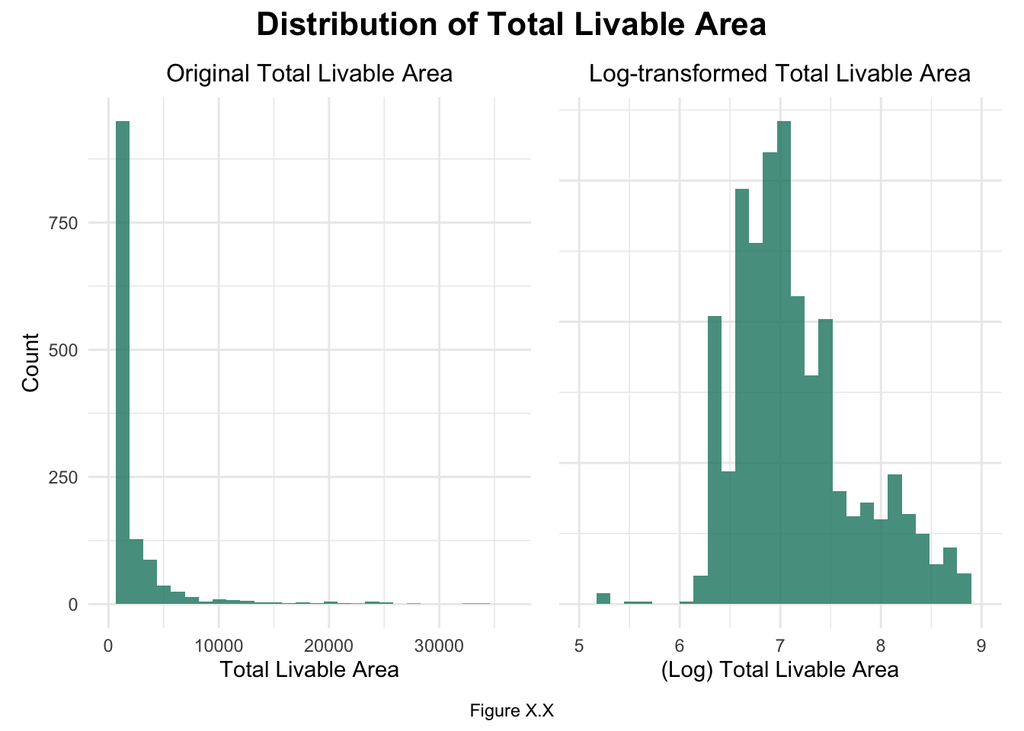

```r
plot_df <- property_final %>%
  mutate(
    total_livable_area_log = log1p(total_livable_area)
  )

plot1 <- ggplot(plot_df, aes(x = total_livable_area)) +
  geom_histogram(bins = 30, fill = "#1B8370", alpha = 0.8) +
  labs(title = "Original Total Livable Area",
        x = "Total Livable Area",
        y = "Count") +
  xlim(0, quantile(plot_df$total_livable_area, 0.99, na.rm = TRUE)) +
  theme_minimal() +
  theme(
    plot.title = element_text(size = 12, hjust = 0.5)
  )

plot2 <- ggplot(plot_df, aes(x = total_livable_area_log)) +
  geom_histogram(bins = 30, fill = "#1B8370", alpha = 0.8) +
  labs(title = "Log-transformed Total Livable Area",
        x = "(Log) Total Livable Area",
        y = "Count")  +
  xlim(5, 9) +
  theme_minimal() +
  theme(
    plot.title = element_text(size = 12, hjust = 0.5),
    axis.title.y = element_blank(),
    axis.text.y = element_blank(),
    axis.ticks.y = element_blank()
  )
combined_plot <- plot1 + plot2 +
  plot_layout(widths = c(1, 1)) +
  plot_annotation(
    title = "Distribution of Total Livable Area",
    caption = "Figure X.X",
    theme = theme(
      plot.title = element_text(size = 16,face = "bold", hjust = 0.5),
      plot.caption = element_text(hjust = 0.5)
    )
  )
combined_plot
```

### 2.2.2 Reclassification

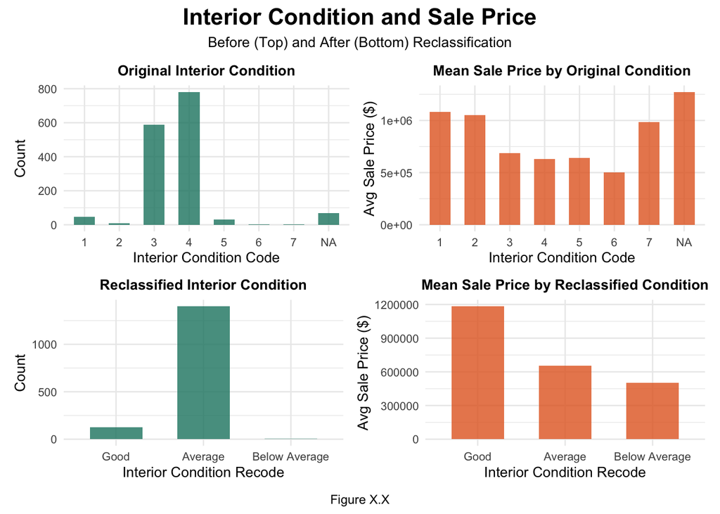

```r
lm1_property <- property_final %>%
  mutate(
    interior_condition_recode = case_when(
      interior_condition %in% c(1,2,7) | is.na(interior_condition) ~ "Good",
      interior_condition %in% c(3,4,5) ~ "Average",
      interior_condition %in% c(6) ~ "Below Average",
      TRUE ~ "Unknown"
    ),
    interior_condition_recode = factor(interior_condition_recode, levels = c("Good", "Average", "Below Average", "Unknown"))
  )
plot1 <- ggplot(lm1_property, aes(x = factor(interior_condition))) +
  geom_bar(fill = "#1B8370", alpha = 0.8, width = 0.6) +
  ggtitle("Original Interior Condition") +
  labs(x = "Interior Condition Code", y = "Count") +
  theme_minimal(base_size = 10) +
  theme(plot.title = element_text(size = 10, face = "bold", hjust = 0.5))

plot2 <- lm1_property %>%
  group_by(interior_condition) %>%
  summarise(mean_log_price = mean(market_value, na.rm = TRUE)) %>%
  ggplot(aes(x = factor(interior_condition), y = mean_log_price)) +
  geom_col(fill = "#E46726", alpha = 0.8, width = 0.6) +
  ggtitle("Mean Sale Price by Original Condition") +
  labs(x = "Interior Condition Code", y = "Avg Sale Price ($)") +
  theme_minimal(base_size = 10) +
  theme(plot.title = element_text(size = 10, face = "bold", hjust = 0.5))

plot3 <- ggplot(lm1_property, aes(x = interior_condition_recode)) +
  geom_bar(fill = "#1B8370", alpha = 0.8, width = 0.6) +
  ggtitle("Reclassified Interior Condition") +
  labs(x = "Interior Condition Recode", y = "Count") +
  theme_minimal(base_size = 10) +
  theme(plot.title = element_text(size = 10, face = "bold", hjust = 0.5))

plot4 <- lm1_property %>%
  group_by(interior_condition_recode) %>%
  summarise(mean_log_price = mean(market_value, na.rm = TRUE)) %>%
  ggplot(aes(x = interior_condition_recode, y = mean_log_price)) +
  geom_col(fill = "#E46726", alpha = 0.8, width = 0.6) +
  ggtitle("Mean Sale Price by Reclassified Condition") +
  labs(x = "Interior Condition Recode", y = "Avg Sale Price ($)") +
  theme_minimal(base_size = 10) +
  theme(plot.title = element_text(size = 10, face = "bold", hjust = 0.5))

# Combine with patchwork + large centered title
combined_plot <- (plot1 + plot2 + plot_layout(tag_level = "new")) /
                 (plot3 + plot4 + plot_layout(tag_level = "new")) +
  plot_annotation(
    title = "Interior Condition and Sale Price",
    subtitle = "Before (Top) and After (Bottom) Reclassification",
    caption = "Figure X.X",
    theme = theme(
      plot.title = element_text(size = 16, face = "bold", hjust = 0.5),
      plot.subtitle = element_text(size = 10, hjust = 0.5),
      plot.caption = element_text(hjust = 0.5),
      plot.title.position = "plot"
    )
  )
combined_plot
```

## 2.3 Comparing North and South - Continuous Variables

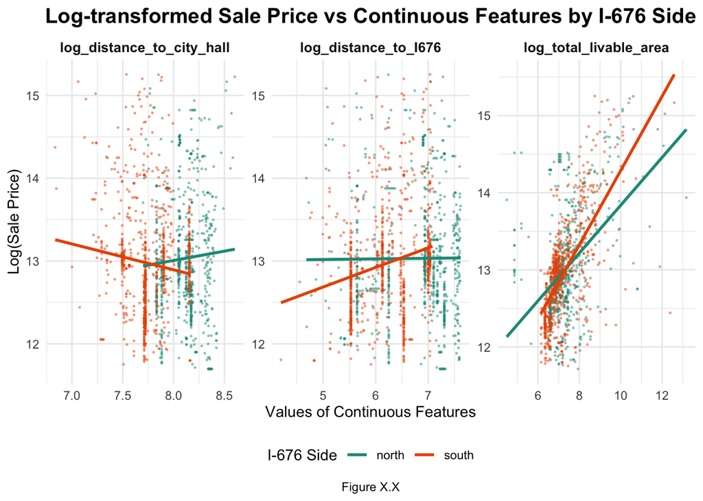

```r
property_fe <- property_CT %>%
  st_drop_geometry() %>%
  mutate(
    log_sale_price = log1p(adj_sale_price),
    log_distance_to_I676 = log1p(distance_to_I676),
    log_distance_to_city_hall = log1p(distance_to_city_hall),
    log_total_livable_area = log1p(total_livable_area),
    I676_NS = as.character(I676_NS)
  )

property_fe_selected <- property_fe %>%
  select(
    I676_NS,
    log_sale_price,
    log_distance_to_I676,
    log_distance_to_city_hall,
    log_total_livable_area
  ) %>%
  drop_na()

correlation_long <- property_fe_selected %>%
  pivot_longer(-c(log_sale_price, I676_NS), names_to = "Variable", values_to = "Value") %>%
  mutate(
    use_in_plot = case_when(
      Variable == "log_total_area" & Value <= log1p(10) ~ FALSE,
      Variable == "log_total_livable_area" & Value <= log1p(10) ~ FALSE,
      TRUE ~ TRUE
    )
  )

cor_selected <- correlation_long %>%
  filter(use_in_plot) %>%
  group_by(Variable, I676_NS) %>%
  summarise(r = cor(Value, log_sale_price, use = "complete.obs"), .groups = "drop") %>%
  mutate(
    x_pos = -Inf,
    y_pos = ifelse(I676_NS == "north", Inf, -Inf),
    vjust_pos = ifelse(I676_NS == "north", 1.1, -1.1)
  )

ggplot(correlation_long %>% filter(use_in_plot),
       aes(x = Value, y = log_sale_price)) +
  geom_point(aes(color = I676_NS), alpha = 0.4, size = 0.3) +
  geom_smooth(aes(color = I676_NS), method = "lm", se = FALSE, linewidth = 1) +
  facet_wrap(~ Variable, scales = "free", ncol = 3) +
  scale_color_manual(values = c("north" = "#1a9988", "south" = "#eb5600")) +
  labs(
    title = "Log-transformed Sale Price vs Continuous Features by I-676 Side",
    caption = "Figure X.X",
    x = "Values of Continuous Features",
    y = "Log(Sale Price)",
    color = "I-676 Side"
  ) +
  theme_minimal() +
  theme(
    plot.title = element_text(size = 15, face = "bold",hjust = 0.5),
    strip.text = element_text(size = 10, face = "bold"),
    plot.caption = element_text(hjust = 0.5),
    legend.position = "bottom"
  )
```

## 2.4 Comparing North and South - Categorical Variables

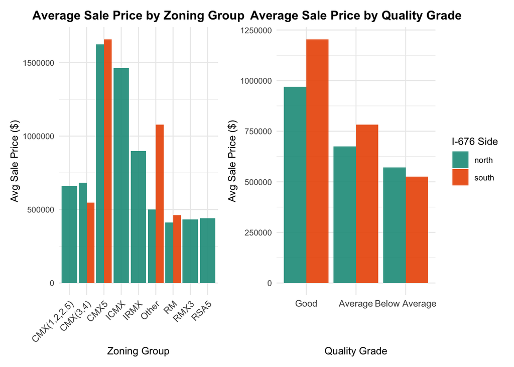

```r
# Prepare aggregated data by zoning group and I676 side
zoning_bar_data <- property_CT %>%
  st_drop_geometry() %>%
  mutate(I676_NS = factor(I676_NS, levels = c("north", "south")))%>%
  filter(!is.na(zoning_group), !is.na(adj_sale_price), !is.na(I676_NS)) %>%
  group_by(zoning_group, I676_NS) %>%
  summarise(mean_sale_price = mean(adj_sale_price, na.rm = TRUE), .groups = "drop")

# Prepare aggregated data by quality grade and I676 side
quality_bar_data <- property_CT %>%
  st_drop_geometry() %>%
  mutate(I676_NS = factor(I676_NS, levels = c("north", "south")))%>%
  filter(!is.na(quality_grade), !is.na(adj_sale_price), !is.na(I676_NS)) %>%
  group_by(quality_grade, I676_NS) %>%
  summarise(mean_sale_price = mean(adj_sale_price, na.rm = TRUE), .groups = "drop")
base_font_size <- 10

plot_zoning <- ggplot(zoning_bar_data, aes(x = zoning_group, y = mean_sale_price, fill = I676_NS)) +
  geom_col(position = "dodge", alpha = 0.9) +
  scale_fill_manual(values = c("north" = "#1a9988", "south" = "#eb5600")) +
  labs(
    title = "Average Sale Price by Zoning Group",
    x = "Zoning Group", y = "Avg Sale Price ($)"
  ) +
  theme_minimal(base_size = base_font_size) +
  theme(
    plot.title = element_text(face = "bold", size = base_font_size + 2, hjust = 0.5),
    axis.text.x = element_text(angle = 45, hjust = 1, size = base_font_size - 1),
    legend.position = "none"
  )

plot_quality <- ggplot(quality_bar_data, aes(x = factor(quality_grade), y = mean_sale_price, fill = I676_NS)) +
  geom_col(position = "dodge", alpha = 0.9) +
  scale_fill_manual(values = c("north" = "#1a9988", "south" = "#eb5600")) +
  labs(
    title = "Average Sale Price by Quality Grade",
    x = "Quality Grade", y = "Avg Sale Price ($)",
    fill = "I-676 Side"
  ) +
  theme_minimal(base_size = base_font_size) +
  theme(
    plot.title = element_text(face = "bold", size = base_font_size + 2, hjust = 0.5),
    axis.text.x = element_text(size = base_font_size - 1)
  )

final_plot <- plot_zoning + plot_quality +
  plot_layout(ncol = 2,  guides = "collect")

final_plot
```

```r
zoning_group_colors <- c(
  "RM" = "#F9844A",
  "RSA5" = "#E89972",
  "RMX3" = "#BFD3C1",
  "CMX5" = "#3B7D64",
  "ICMX" = "#004B40",
  "IRMX" = "#FFDAB9",
  "RMX1" = "#F9C74F",
  "SPPOA" = "#F8961E",
  "CMX(1,2,2.5)" = "#43AA8B",
  "CMX(3,4)" = "#90BE6D",
  "Other" = "grey80"
)

ggplot() +
  geom_sf(data = block2023_studyarea, fill = "grey95", color = "grey80", size = 0.3) +
  geom_sf(data = I676_2, color = "red", size = 1, alpha = 0.9) +
  geom_sf(data = property_CT %>% filter(!is.na(zoning_group)),
          aes(color = zoning_group), size = 1, alpha = 0.7) +
  scale_color_manual(values = zoning_group_colors, na.translate = FALSE) +
  labs(
    title = "Zoning Groups of Properties within Study Area",
    subtitle = "Study Area Around I676",
    caption = "Figure X.X",
    color = "Zoning Group"
  ) +
  theme_void() +
  theme(
    plot.title = element_text(size = 16, face = "bold"),
    plot.subtitle = element_text(size = 12),
    plot.caption = element_text(hjust = 0.5),
    legend.title = element_text(size = 9),
    legend.text = element_text(size = 8),
    panel.border = element_rect(color = "black", fill = NA, size = 1)
  )
```

[output not shown]

```r
ggplot() +
  geom_sf(data = block2023_studyarea, fill = "grey95", color = "grey80", size = 0.3) +
  geom_sf(data = I676_2, color = "red", size = 1, alpha = 0.9) +
  geom_sf(
  data = property_CT %>% filter(!is.na(LPSS_PER1000)),
  aes(color = LPSS_PER1000),
  size = 1,
  alpha = 0.8
) +
scale_color_manual(
  values = c(
    "low" = "#FFDDAB",
    "mid" = "#E89972",
    "high" = "#004B40",
    "Unknown" = "grey70"
  ),
  name = "LPSS Level"
) +

  labs(
    title = "Low Produce Supply Score (LPSS) within Study Area",
    subtitle = "Darker = Higher LPSS, i.e., More Limited Access",
    caption = "Figure X.X"
  ) +
  theme_void() +
  theme(
    plot.title = element_text(size = 16, face = "bold"),
    plot.subtitle = element_text(size = 12),
    plot.caption = element_text(hjust = 0.5),
    legend.title = element_text(size = 9),
    legend.text = element_text(size = 8),
    panel.border = element_rect(color = "black", fill = NA, size = 1)
  )
```

[output not shown]

# 3 Model

## 3.1 OLS Model

```r
lm_CT <- lm(
  log(adj_sale_price) ~
    log_dist_highway +
    log(distance_to_city_hall+1) +
#    distance_to_nearest_transit +
#    distance_to_nearest_school +
#    distance_to_nearest_hospital +
#    log(distance_to_nearest_bikelane) +
    log(nearest_restaurant_dist_m + 1) +
    log(distance_to_nearest_park + 1) +
    zoning_group +
    zip_code +
    landuse+
    nhoods_name+
    exterior_condition +
    interior_condition +
    log(total_livable_area + 1) +
    number_of_bathrooms +
    number_of_bedrooms +
    quality_grade +
    log(distance_to_nearest_water + 1) +
    central_air +
    year_built_group +
 #   year_built_missing +
    LPSS_PER1000+
#    HPSS_PER1000+
    general_construction +
    garage_spaces +
    separate_utilities +
#    central_air_missing +
#    category_code +
    crime_nn5,
#    general_construction_missing +
#    number_of_bathrooms_missing +
#    number_of_bedrooms_missing +
#    separate_utilities_missing,
  data = property_CT
)

model_summary <- tidy(lm_CT) %>%
  mutate(
    p.value = signif(p.value, 3),
    estimate = round(estimate, 3),
    std.error = round(std.error, 3),
    statistic = round(statistic, 2),
    sig = case_when(
      p.value < 0.001 ~ "***",
      p.value < 0.01  ~ "**",
      p.value < 0.05  ~ "*",
      p.value < 0.1   ~ ".",
      TRUE ~ ""
    )
  ) %>%
  select(term, estimate, std.error, statistic, p.value, sig)
predicted <- predict(lm_CT)
actual <- log(property_CT$adj_sale_price)
rmse <- sqrt(mean((predicted - actual)^2, na.rm = TRUE))

glance_stats <- glance(lm_CT)
model_stats <- tibble(
  term = c("R-squared", "Adj. R-squared", "Num. Obs.", "RMSE"),
  estimate = c(
    round(glance_stats$r.squared, 3),
    round(glance_stats$adj.r.squared, 3),
    glance_stats$nobs,
    round(rmse, 3)
  ),
  std.error = NA, statistic = NA, p.value = NA, sig = ""
)
model_full <- bind_rows(model_summary, model_stats)

model_full %>%
  kable("html", caption = "OLS Regression Results", digits = 3, align = "c") %>%
  kable_styling(
    full_width = FALSE,
    bootstrap_options = c("striped", "hover", "condensed"),
    position = "center"
  ) %>%
  row_spec(0, bold = TRUE, background = "#1a9988", color = "white") %>%
  scroll_box(height = "350px")
```

OLS Regression Results

term

estimate

std.error

statistic

p.value

sig

(Intercept)

27.707

3.864

7.17

0.000

***

log_dist_highway

0.185

0.040

4.58

0.000

***

log(distance_to_city_hall + 1)

-0.708

0.202

-3.50

0.000

***

log(nearest_restaurant_dist_m + 1)

-0.017

0.029

-0.58

0.564

log(distance_to_nearest_park + 1)

-0.172

0.037

-4.66

0.000

***

zoning_groupCMX(3,4)

-0.132

0.103

-1.27

0.203

zoning_groupCMX5

0.173

0.212

0.81

0.417

zoning_groupICMX

0.437

0.192

2.27

0.023

zoning_groupIRMX

-0.143

0.136

-1.05

0.292

zoning_groupOther

-0.209

0.143

-1.46

0.145

zoning_groupRM

-0.374

0.121

-3.11

0.002

zoning_groupRMX3

-0.250

0.116

-2.15

0.032

zoning_groupRSA5

-0.186

0.146

-1.28

0.202

zip_code19106

-0.597

0.346

-1.72

0.085

.

zip_code19107

-0.573

0.331

-1.73

0.084

.

zip_code19123

-0.707

0.349

-2.03

0.043

zip_code19130

-0.401

0.384

-1.04

0.297

landuseOpen Space/Business

0.048

0.072

0.67

0.504

landuseResidential High/Civic

0.062

0.059

1.05

0.292

landuseResidential Medium

-0.005

0.088

-0.05

0.959

landuseVacant

-1.063

0.146

-7.26

0.000

***

nhoods_nameCHINATOWN

0.000

0.080

-0.01

0.996

nhoods_nameEAST_POPLAR

1.254

0.277

4.52

0.000

***

nhoods_nameOLD_CITY

-0.391

0.124

-3.15

0.002

nhoods_nameWEST_PART

0.094

0.118

0.80

0.424

nhoods_nameWEST_POPLAR

0.102

0.107

0.96

0.338

exterior_conditionBelow Average

0.173

0.268

0.64

0.520

exterior_conditionGood

-0.102

0.300

-0.34

0.734

interior_conditionBelow Average

0.660

0.434

1.52

0.129

interior_conditionGood

0.496

0.249

1.99

0.047

log(total_livable_area + 1)

0.210

0.022

9.54

0.000

***

number_of_bathrooms1

-0.357

0.074

-4.84

0.000

***

number_of_bathrooms2

-0.112

0.095

-1.17

0.241

number_of_bathrooms3-5

0.053

0.153

0.35

0.728

number_of_bathrooms6

0.050

0.615

0.08

0.935

number_of_bathrooms7

0.987

0.585

1.69

0.092

.

number_of_bathroomsUnknown

0.827

0.357

2.31

0.021

number_of_bedrooms1

0.169

0.082

2.07

0.039

number_of_bedrooms2

0.201

0.064

3.15

0.002

number_of_bedrooms3

0.223

0.187

1.19

0.234

number_of_bedrooms4

0.132

0.165

0.80

0.425

number_of_bedrooms5

-1.413

0.567

-2.49

0.013

number_of_bedroomsUnknown

-0.323

0.345

-0.94

0.349

quality_gradeAverage

-0.044

0.111

-0.39

0.694

quality_gradeBelow Average

0.060

0.088

0.69

0.491

log(distance_to_nearest_water + 1)

-1.121

0.308

-3.64

0.000

***

central_airUnknown

-0.018

0.105

-0.18

0.861

central_airY

0.096

0.102

0.95

0.342

year_built_group1900- 1930

-0.537

0.181

-2.97

0.003

year_built_group1930 - 1970

-0.326

0.187

-1.74

0.082

.

year_built_group1970 - 2010

-0.463

0.190

-2.44

0.015

year_built_group2010+

-0.513

0.223

-2.30

0.022

year_built_groupUnknown

0.912

0.301

3.03

0.002

LPSS_PER1000

-0.015

0.004

-3.84

0.000

***

general_construction4

-0.321

0.344

-0.93

0.351

general_construction5

-0.133

0.649

-0.20

0.838

general_construction9

-0.241

0.608

-0.40

0.692

general_constructionA

-0.255

0.287

-0.89

0.373

general_constructionB

-0.511

0.285

-1.79

0.073

.

general_constructionC

-0.492

0.338

-1.46

0.146

general_constructionD

-0.742

0.587

-1.26

0.206

general_constructionE

-0.443

0.499

-0.89

0.375

general_constructionF

-0.007

0.313

-0.02

0.983

general_constructionG

-1.157

0.355

-3.26

0.001

general_constructionH

0.385

0.282

1.36

0.173

general_constructionUnknown

-0.096

0.289

-0.33

0.739

garage_spacesless than 2

0.086

0.204

0.42

0.671

separate_utilitiesB

0.016

0.165

0.09

0.925

separate_utilitiesC

0.139

0.108

1.29

0.198

separate_utilitiesUnknown

0.183

0.084

2.18

0.029

crime_nn5

0.003

0.001

5.70

0.000

***

R-squared

0.480

NA

NA

NA

Adj. R-squared

0.455

NA

NA

NA

Num. Obs.

1528.000

NA

NA

NA

RMSE

0.503

NA

NA

NA

```r
feature_lookup <- tibble(
  Variable = c(
    "log_dist_highway",
    "log(distance_to_city_hall + 1)",
    "log(nearest_restaurant_dist_m + 1)",
    "log(distance_to_nearest_park + 1)",
    "zoning_group",
    "zip_code",
    "exterior_condition",
    "interior_condition",
    "log1p(total_livable_area)",
    "number_of_bathrooms",
    "number_of_bedrooms",
    "quality_grade",
    "log(distance_to_nearest_water + 1)",
    "central_air",
    "year_built_group",
    "LPSS_PER1000",
    "general_construction",
    "garage_spaces",
    "separate_utilities",
    "category_code",
    "crime_nn5",
    "landuse",
    "nhoods_name"
  ),
  Feature = c(
    "Log Distance to Highway",
    "Log Distance to City Hall",
    "Log Distance to Nearest Restaurant",
    "Log Distance to Nearest Park",
    "Zoning Group",
    "Zip Code",
    "Exterior Condition",
    "Interior Condition",
    "Log Total Livable Area",
    "Number of Bathrooms",
    "Number of Bedrooms",
    "Quality Grade",
    "Log Distance to Nearest Water",
    "Central Air",
    "Year Built",
    "Low-Produce Supply Stores per 1000",
    "General Construction",
    "Garage Spaces",
    "Separate Utilities",
    "Category Code",
    "Crime Rate (NN5)",
    "Land Use",
    "Neighborhood"
  )
)

vif_df <- car::vif(lm_CT) %>%
  as.data.frame() %>%
  rownames_to_column("Variable") %>%
  as_tibble() %>%
  rename(
    GVIF = `GVIF`,
    Df = `Df`,
    VIF = `GVIF^(1/(2*Df))`
  ) %>%
  mutate(
    VIF = round(VIF, 2),
    Level = case_when(
      VIF >= 10 ~ "Very High",
      VIF >= 5 ~ "High",
      VIF < 5 ~ "OK",
      TRUE ~ "Unknown"
    )
  )

vif_table <- vif_df %>%
  left_join(feature_lookup, by = "Variable") %>%
  select(Variable, Feature, VIF, Level)
vif_table %>%
  kable("html", caption = "VIF (GVIF-adjusted) with Feature Descriptions", align = "c") %>%
  kable_styling(
    full_width = FALSE,
    bootstrap_options = c("striped", "hover", "condensed"),
    position = "center"
  ) %>%
  row_spec(0, bold = TRUE, background = "#1a9988", color = "white") %>%
  row_spec(which(vif_table$VIF >= 5), background = "#eb5600") %>%
  scroll_box(height = "300px")
```

VIF (GVIF-adjusted) with Feature Descriptions

| Variable | Feature | VIF | Level |
| --- | --- | --- | --- |
| log_dist_highway | Log Distance to Highway | 2.14 | OK |
| log(distance_to_city_hall + 1) | Log Distance to City Hall | 4.20 | OK |
| log(nearest_restaurant_dist_m + 1) | Log Distance to Nearest Restaurant | 2.07 | OK |
| log(distance_to_nearest_park + 1) | Log Distance to Nearest Park | 2.17 | OK |
| zoning_group | Zoning Group | 1.33 | OK |
| zip_code | Zip Code | 2.35 | OK |
| landuse | Land Use | 1.55 | OK |
| nhoods_name | Neighborhood | 1.98 | OK |
| exterior_condition | Exterior Condition | 2.51 | OK |
| interior_condition | Interior Condition | 2.49 | OK |
| log(total_livable_area + 1) | NA | 3.11 | OK |
| number_of_bathrooms | Number of Bathrooms | 2.16 | OK |
| number_of_bedrooms | Number of Bedrooms | 2.09 | OK |
| quality_grade | Quality Grade | 1.46 | OK |
| log(distance_to_nearest_water + 1) | Log Distance to Nearest Water | 3.16 | OK |
| central_air | Central Air | 1.70 | OK |
| year_built_group | Year Built | 1.90 | OK |
| LPSS_PER1000 | Low-Produce Supply Stores per 1000 | 4.50 | OK |
| general_construction | General Construction | 1.21 | OK |
| garage_spaces | Garage Spaces | 6.92 | High |
| separate_utilities | Separate Utilities | 1.21 | OK |
| crime_nn5 | Crime Rate (NN5) | 1.78 | OK |

## 3.2 OLS predictive model

```r
set.seed(123)
split <- initial_split(property_CT, prop = 0.8)  # 80% train, 20% test

train_data <- training(split)
test_data <- testing(split)
```

```r
lm_train <- lm(
  log(adj_sale_price) ~
    log_dist_highway +
    log(distance_to_city_hall+1) +
#    distance_to_nearest_transit +
#    distance_to_nearest_school +
#    distance_to_nearest_hospital +
#    log(distance_to_nearest_bikelane) +
    log(nearest_restaurant_dist_m + 1) +
    log(distance_to_nearest_park + 1) +
    zoning_group +
    zip_code +
    exterior_condition +
    interior_condition +
    log1p(total_livable_area) +
    distance_to_nearest_hospital +
    number_of_bathrooms +
    number_of_bedrooms +
    quality_grade +
    log(distance_to_nearest_water + 1) +
    central_air +
    year_built_group +
    nhoods_name+
    landuse+
#    year_built_missing +
    LPSS_PER1000+
#    HPSS_PER1000+
    general_construction +
    garage_spaces +
    separate_utilities +
    category_code +
    crime_nn5,
  data = train_data
)
```

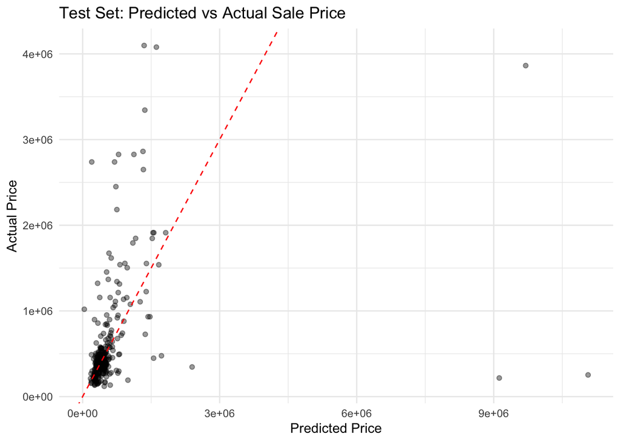

```r
test_data$log_pred <- predict(lm_train, newdata = test_data)
test_data$price_pred <- exp(test_data$log_pred) - 1

test_data <- test_data %>%
  mutate(
    abs_error = abs(price_pred - adj_sale_price),
    pct_error = abs_error / adj_sale_price
  )
#mean(test_data$pct_error, na.rm = TRUE)
#median(test_data$pct_error, na.rm = TRUE)

ggplot(test_data, aes(x = price_pred, y = adj_sale_price)) +
  geom_point(alpha = 0.4) +
  geom_abline(slope = 1, intercept = 0, color = "red", linetype = "dashed") +
  labs(
    title = "Test Set: Predicted vs Actual Sale Price",
    x = "Predicted Price",
    y = "Actual Price"
  ) +
  theme_minimal()
```

```r
rmse_value <- sqrt(mean((test_data$price_pred - test_data$adj_sale_price)^2, na.rm = TRUE))
mae_value <- mean(abs(test_data$price_pred - test_data$adj_sale_price), na.rm = TRUE)
```

```r
property_predict <- property_CT %>%
  mutate(
    log_price = log(adj_sale_price),
    log_pred = predict(lm_train, newdata = .)
  )
st_write(property_predict, "property_pred_OLS.geojson", driver = "GeoJSON", delete_dsn = TRUE)
comparison_df <- property_predict %>%
  select(location, log_price, log_pred)
```